# S2 - NPIs

This electronic supplementary material aims to document, in a reproducible manner, the simulation results presented in the main text regarding the sub-models representing the non-pharmaceutical interventions (**NPIs**).

# 1 Testing & Isolation (*T&I*)

## 1.1 Equations

Compared to the SEI3R model (*1A_SEI3R.stmx*), T&I models (*2A_TI_fixed_fractions.stmx* & *2B_TI_Logistic.stmx*) modify the dynamics of transmission in the following way:

$$\begin{equation} \label{eq:1}
\begin{aligned}
\dot{P^d_t} &= \theta_t \omega \sigma E_t - \nu P^d_t\\
\dot{P_t} &= (1- \theta_t) \omega \sigma E_t - \nu P_t\\
\dot{I^d_t} &= \nu P^d_t - \gamma I^d_t\\
\dot{R_t} &= \gamma (I_t + I^d_t) + \kappa A_t \\
\lambda_t &= \frac{\beta (P_t + I_t + P^d_t + (1 -\iota^d)
I^d_t + \eta A_t)}{N}
\end{aligned}
\end{equation}$$

## 1.2 Comparison

### 1.2.1 Fixed testing fraction

First, we simulate the *T&I* with a constant testing fraction ($\theta^d$) under three scenarios, where $\theta$ takes the following values: *0%*, *25%*, *50%*.

```r
# Model with a constant intervention
c_mdl <- read_xmile("./models/2A_TI_fixed_fractions.stmx",
                    const_list = c(bio_params))

theta_df <- data.frame(par_theta_d = c(0, 0.25, 0.5))

f_t_sens_df <- sd_sensitivity_run(c_mdl$deSolve_components,
                              consts_df = theta_df,
                              integ_method = "euler", start_time = 0,
                              stop_time = 1000, timestep = 1 / 64,
                              multicore = TRUE, n_cores = 3,
                              reporting_interval = 1 / 8) |>
  mutate(c = C / N)
```

```r
# Fixed testing
f_t_df <- f_t_sens_df |>
  filter(time > 0 & time <= 150) |>
  select(time, c, E_to_Pd, par_theta_d) |>
  mutate(E_to_Pd = 1000 * E_to_Pd / pop_val,
         c = c * 100,
         var_theta = par_theta_d * 100) |>
  pivot_longer(c(-time, -par_theta_d)) |>
  mutate(par_theta_d = percent(par_theta_d),
         name = case_when(name == "c" ~ "Attack rate [%]",
                          name == "E_to_Pd" ~ "Daily tests per 1000 population",
                          name == "var_theta" ~"Testing fraction [%]"))
```

### 1.2.2 Time-varying testing fraction

We model the time-varying testing fraction using the logistic growth model. To configure this structure, we employ data[^1] from the COVID-19 pandemic in the Netherlands (see below) and model calibration to estimate the logistic growth model’s parameters.

- In March 2020 the reported test capacity in the Netherlands was 4000 tests per day.
- In June 2020 the Netherlands was able to conduct 30.000 tests per day.
- By the end of 2020 the capacity has grown to 120.000 tests per day.
- In April 2021 the capacity had grown to 175.000 test per day.

```r
data_df <- data.frame(time  = c(0, 90, 300, 390),
                      value = c(4000, 30000, 120000, 175000)) |>
  mutate(value = value * 1000 / pop_val)

est_obj <- estimate_rho(data_df)
rho_est <- est_obj$estimate

# Testing capacity parameters
tc_pars <- data.frame(name  = c("alpha_d", "rho_d", "Qd"),
                      value = c(data_df[4, 2], rho_est, data_df[1, 2])) |>
  write_csv("./Data/Testing_capacity_pars.csv")
```

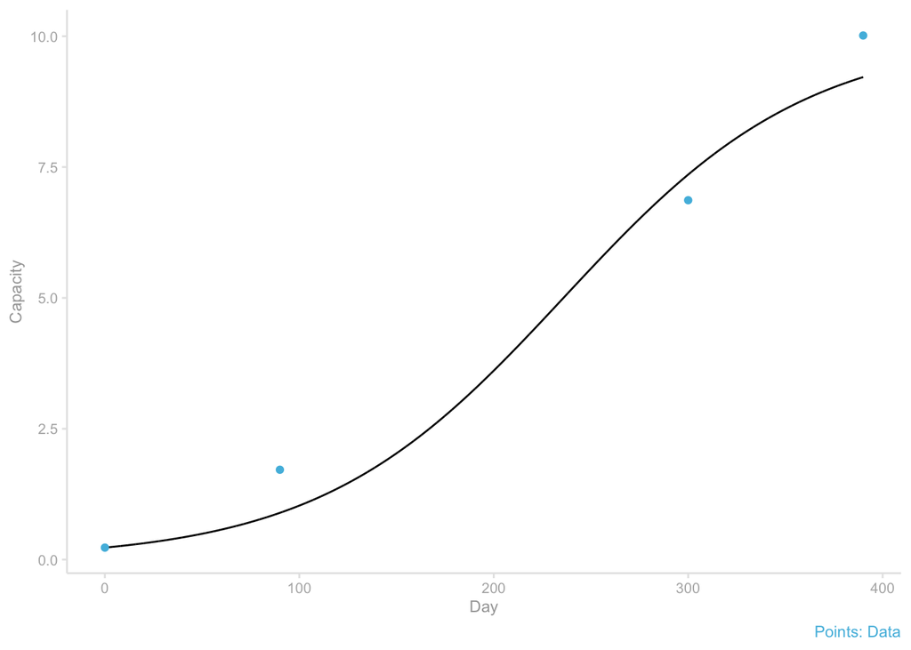

```r
plot_fit(est_obj$sim, data_df)
```

Using the capacity estimates, we simulate the *testing and isolation* model.

```r
fp <- "./models/2B_TI_Logistic.stmx"

iota_mid <- 0.51

alpha_d_val <- data_df[4, 2]
Qd_init     <- data_df[1, 2]

mdl       <- read_xmile(fp,
                        stock_list = list(Qd = Qd_init),
                        const_list = c(bio_params,
                                       par_beta    = beta_vals[[2]],
                                       par_alpha_d = alpha_d_val,
                                       par_rho_d   = rho_est,
                                       par_iota_d  = 0.51,
                                       par_delta   = 0.60))
ds_inputs <- mdl$deSolve_components

output <- sd_simulate(ds_inputs, start_time = 0, stop_time = 1000,
                      timestep = 1 / 64,
                      integ_method = "euler") |>
  mutate(c     = C / pop_val)
```

```r
# This data frame summarises key indicators from the previous simulation
tv_df <- output |> select(time, c, E_to_Pd, Qd, var_theta) |>
  mutate(E_to_Pd = 1000 * E_to_Pd / pop_val,
         c = c * 100,
         var_theta = var_theta * 100) |>
  filter(time > 0 & time <= 150) |>
  pivot_longer(-time) |>
  mutate(name = case_when(name == "c" ~ "Attack rate [%]",
                          name == "E_to_Pd" ~ "Daily tests per 1000 population",
                          name == "Qd" ~ "Testing capacity per 1000 population",
                          name == "var_theta" ~"Testing fraction [%]"))
```

This table compares the attack rate at day 150 between the two assumptions (fixed and time-varying testing rates).

```r
tv_attack_rate <- output |> filter(time == 150) |>
  mutate(par_theta_d = "Time-varying",
         c         = percent(round(c, 2))) |>
  select(par_theta_d, C, c)

f_t_sens_df |> filter(time == 150) |> select(par_theta_d, C, c) |>
  mutate(par_theta_d = percent(par_theta_d),
         c         = percent(round(c, 2))) |>
  bind_rows(tv_attack_rate) |>
  gt() |>
    cols_label(
    par_theta_d = html("Testing fraction (&theta;<sup>d</sup>)"),
    c = html("Attack rate by day 150 (c<sub>150</sub>)"),
    C = html("Cumulative infections by day 150 (C<sub>150</sub>)")) |>
    tab_style(
      style = list(
      cell_text(color = "#0363BB")),
    locations = cells_body(
      rows = 4))
```

| Testing fraction (θ<sup>d</sup>) | Cumulative infections by day 150 (C<sub>150</sub>) | Attack rate by day 150 (c<sub>150</sub>) |
| --- | --- | --- |
| 0% | 16439034 | 94% |
| 25% | 16109435 | 92% |
| 50% | 15660104 | 90% |
| Time-varying | 16403071 | 94% |

# 2 Testing, tracing and Isolation (*TTI*)

TTI refers to the combined strategy of testing and isolation plus contact tracing.

## 2.1 Equations

Compared to the T&I models (*2A_TI_fixed_fractions.stmx* & *2B_TI_Logistic.stmx*), the TTI structure (*2C_TTI_Logistic.stmx* & *2D_TTI_fixed_fractions.stmx*) modify the dynamics of transmission in the following way:

$$\begin{equation} \label{eq:2}
\begin{aligned}
\dot{S_t} &= -\lambda_t S_t + \frac{S^q_t}{\sigma^-{1} +
\nu^{-1} +
\gamma^{-1}} - \mu^s_t S_t - \mu^i_t S_t \\
\dot{S^q_t} &= \mu^s_t S_t - \frac{S^q_t}{\sigma^-{1} +
\nu^{-1} +\gamma^{-1}}\\
\dot{E^q_t} &= \mu^i_t S_t - \sigma E^q_t\\
\dot{P^q_t} &= \omega \sigma E^q_t - \nu P^q_t\\
\dot{I^q_t} &= \nu P^q_t - \gamma I^q_t\\
\dot{A^q_t} &= (1 - \omega) \sigma E^q_t - \kappa A^q_t\\
\dot{R_t} &= \gamma (I_t + I^d_t + I^q_t) + \kappa (A_t +
A^q_t) \\
\lambda_t &= \lambda^{P}_t + \lambda^{P^d}_t +
\lambda^{P^q}_t +
\lambda^{I}_t + \lambda^{I^d}_t + \lambda^{I^q}_t + \lambda^{A}_t
+
\lambda^{A^q}_t\\
\lambda^{P^q}_t &= (1 - \iota^d) \frac{\beta P^q_t} {N}\\
\lambda^{I^q}_t &= (1 - \iota^d) \frac{\beta I^q_t} {N} \\
\lambda^{A^q}_t &= (1 - \iota^d) \frac{\eta \beta A^q_t}{N} \\
\lambda^{P^d}_t &= \frac{\upsilon (\zeta - \zeta^k_t) P^d_t}{N}
\\
D^k_t &= \zeta P^d_t\\
k_t &= \min(D^k_t , Q^k_t) \\
\zeta^k_t &= \begin{cases}
0, P^d = 0 \\
\frac{k_t}{P^d}, P^d > 0
\end{cases}\\
\mu^s_t &= \frac{(1 - \upsilon) \zeta^k_t P_t^d}{N}\\
\mu^i_t &= \frac{\upsilon \zeta^k_t P_t^d}{N}
\end{aligned}
\end{equation}$$

## 2.2 Comparison

### 2.2.1 Fixed testing & tracing fractions

We simulate the *TTI* model with constant testing ($\theta^d$) and tracing ($\theta^k$) fractions underthree scenarios. These fractions can take the following values: *0%*, *25%*, *50%*.

```r
# Testing, tracing, and isolation with fixed testing and tracing fractions
f_ct_path <- "./models/2D_TTI_fixed_fractions.stmx"

f_ct_mdl <- read_xmile(f_ct_path,
                       const_list = c(bio_params,
                                      par_zeta = zeta_val))

theta_df <- data.frame(par_theta_d = c(0, 0.25, 0.5),
                       par_theta_k = c(0, 0.25, 0.5))

c_sens_df <- sd_sensitivity_run(f_ct_mdl$deSolve_components,
                              consts_df = theta_df,
                              integ_method = "euler", start_time = 0,
                              stop_time = 1000, timestep = 1 / 64,
                              multicore = TRUE, n_cores = 3,
                              reporting_interval = 1 / 8) |>
  mutate(c = C / N)
```

```r
# Fixed testing & tracing
f_ct_df <- c_sens_df |>
  filter(time > 0 & time <= 150) |>
  select(time, c, k, par_theta_k) |>
  mutate(c = c * 100,
         tracing_rate     = 1000 * k / pop_val,
         var_theta_k = par_theta_k * 100) |>
  select(-k) |>
  pivot_longer(c(-time, -par_theta_k)) |>
  mutate(par_theta_k = percent(par_theta_k),
         name = case_when(name == "c" ~ "Attack rate [%]",
                          name == "tracing_rate" ~ "Daily tracings per 1000 population",
                          name == "var_theta_k" ~"Tracing fraction [%]"))
```

### 2.2.2 Time-varying testing fraction

We model the time-varying tracing fraction using the logistic growth model. To configure this structure, we employ data[^2] from the COVID-19 pandemic in the Netherlands (see below) and model calibration to estimate the logistic growth model’s parameters.

At the start of the pandemic tracing capacity was around 200-220 FTE. By May 2020, this value tripled to 670 FTE. From June 2020, the capacity of the GGD was significantly expanded to a total of 1250 FTE. By the end of September 2020, this capacity was expected to reach 3250 FTE.

```r
data_FTE <- data.frame(time  = c(0, 60, 90, 210),
                      value = c(200, 670, 1250, 3250))

est_obj     <- estimate_rho(data_FTE)
rho_k_est   <- est_obj$estimate
```

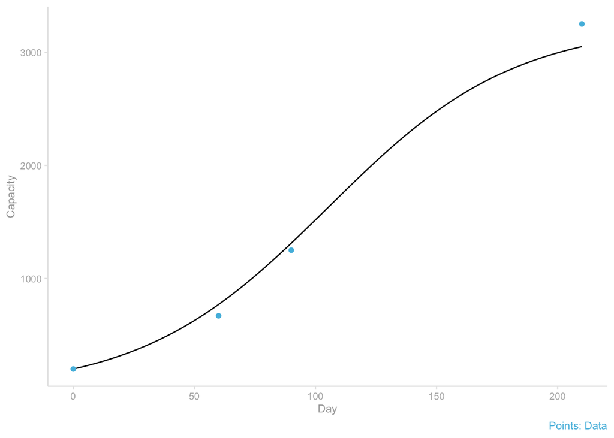

```r
plot_fit(est_obj$sim, data_FTE)
```

Using the capacity estimates, we simulate the *TTI* model.

```r
fp_ct <- "./models/2C_TTI_Logistic.stmx"

zeta_val   <- beta_vals[[2]] * 10

# Number of index cases traced per week per FTE
idx_val <- 3

Qk_init     <- (data_FTE[1, 2] * idx_val * zeta_val / 7) * (1000 / pop_val)
alpha_k_val <- (data_FTE[4, 2] * idx_val * zeta_val / 7) * (1000 / pop_val)

iota_mid <- 0.51

alpha_d_val <- data_df[4, 2]

ct_pars <- data.frame(name  = c("alpha_k", "rho_k", "Qk"),
                      value = c(alpha_k_val, rho_k_est, Qk_init)) |>
  write_csv("./Data/Tracing_capacity_pars.csv")

mdl       <- read_xmile(fp_ct, stock_list = list(Qd = data_df[1, 2],
                                              Qk = Qk_init),
                        const_list = c(bio_params,
                                       par_zeta    = zeta_val,
                                       par_alpha_d = alpha_d_val,
                                       par_alpha_k = alpha_k_val,
                                       par_rho_d   = rho_est,
                                       par_rho_k   = rho_k_est,
                                       par_iota_d  = 0.51,
                                       par_delta   = 0.60))
ds_inputs <- mdl$deSolve_components

sim_output <- sd_simulate(ds_inputs, start_time = 0, stop_time = 300,
                          timestep = 1 / 64, integ_method = "euler") |>
  mutate(c = C / N)
```

```r
# Time-varying (tv) contact tracing (ct)
tv_ct_df <- sim_output  |> select(time, c, k, Qk, Dk) |>
  mutate(c                = c * 100,
         tracing_rate     = 1000 * k / pop_val,
         tracing_fraction = k/Dk * 100) |>
  filter(time > 0 & time <= 150) |>
  select(-k, -Dk) |>
  pivot_longer(-time) |>
  mutate(name = case_when(name == "c" ~ "Attack rate [%]",
                          name == "tracing_rate" ~ "Daily tracings per 1000 population",
                          name == "Qk" ~ "Tracing capacity per 1000 population",
                          name == "tracing_fraction" ~"Tracing fraction [%]"))
```

This table compares the attack rate at day 150 between the two assumptions (fixed and time-varying testing rates).

```r
ct_tv_df <- sim_output |> filter(time == 150) |>
  mutate(par_theta_k = "Time-varying",
         c         = percent(round(c, 2))) |>
  select(par_theta_k, c, C)

c_sens_df |> filter(time == 150) |> select(par_theta_k, c, C) |>
  mutate(par_theta_k = percent(par_theta_k),
         c         = percent(round(c, 2))) |>
  bind_rows(ct_tv_df) |>
  gt() |>
    cols_label(
    par_theta_k = html("Testing & tracing fraction (&theta;)"),
    c = html("Attack rate at day 150 (c<sub>150</sub>)"),
    C = html("Cumulative infections by day 150 (C<sub>150</sub>)")) |>
    tab_style(
      style = list(
      cell_text(color = "#0363BB")),
    locations = cells_body(
      rows = 4))
```

| Testing & tracing fraction (θ) | Attack rate at day 150 (c<sub>150</sub>) | Cumulative infections by day 150 (C<sub>150</sub>) |
| --- | --- | --- |
| 0% | 94% | 16439033 |
| 25% | 88% | 15443554 |
| 50% | 78% | 13635840 |
| Time-varying | 94% | 16392787 |

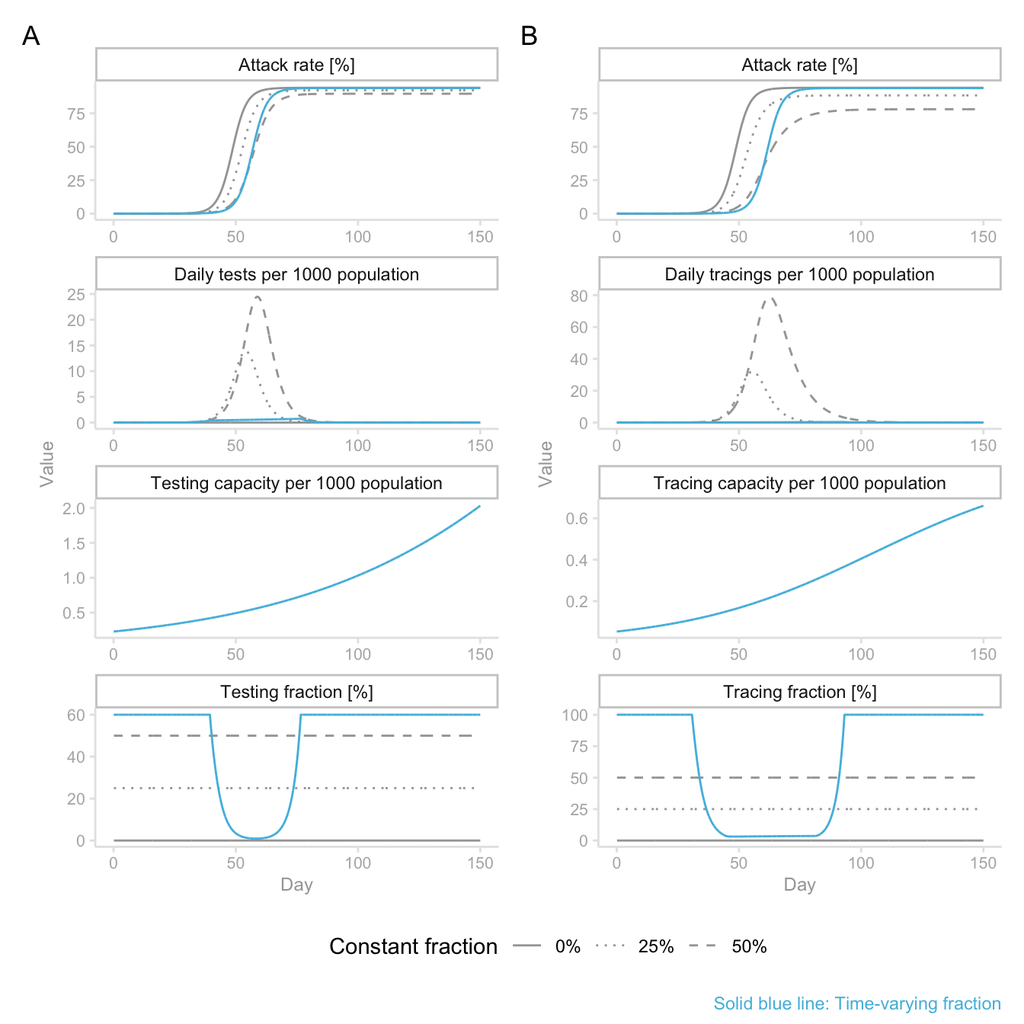

```r
g <- plot_fig_04(tv_df, f_t_df, tv_ct_df, f_ct_df)

ggsave("./plots/Fig_04_TI_CT.pdf", plot = g,
       height = 7, width = 7, device = cairo_pdf)

g
```

## 2.3 Testing and tracing scenarios

```r
ref_testing <- tc_pars |> pivot_wider() |>
  rename(par_alpha_d = alpha_d,
         par_rho_d = rho_d)

test_sc_1 <- ref_testing |> mutate(par_rho_d = par_rho_d * 2,
                                   Testing_scenario = "t1")

test_sc_2 <- ref_testing |> mutate(par_rho_d = 0,
                                   Qd = par_alpha_d,
                                   Testing_scenario = "t2")

test_sc_3 <- ref_testing |> mutate(par_rho_d = 0,
                                   par_alpha_d = par_alpha_d * 2,
                                   Qd = par_alpha_d,
                                   Testing_scenario = "t3")

test_sc <- bind_rows(test_sc_1, test_sc_2, test_sc_3)
```

```r
ref_tracing <- ct_pars |> pivot_wider() |>
  rename(par_alpha_k = alpha_k,
         par_rho_k = rho_k)

trac_sc_1 <- ref_tracing  |> mutate(par_rho_k = par_rho_k * 2,
                                   Tracing_scenario = "c1")

trac_sc_2 <- ref_tracing  |> mutate(par_rho_k = 0,
                                    Qk = par_alpha_k,
                                    Tracing_scenario = "c2")

trac_sc_3 <- ref_tracing  |> mutate(par_rho_k   = 0,
                                    par_alpha_k = par_alpha_k * 2,
                                    Qk          = par_alpha_k,
                                   Tracing_scenario = "c3")

trac_sc <- bind_rows(trac_sc_1, trac_sc_2, trac_sc_3)
```

```r
scenarios_df <- expand.grid(Testing_scenario = paste0("t", 1:3),
            Tracing_scenario = paste0("c", 1:3)) |>
  left_join(test_sc) |>
  left_join(trac_sc) |>
  mutate(iter = row_number())
```

```r
scenarios_df |>
  select(-iter) |>
  mutate(across(where(is.numeric),~round(.x, 2))) |>
  gt() |>
    cols_label(
    par_alpha_d      = html("&alpha;<sup>d</sup>"),
    par_rho_d        = html("&rho;<sup>d</sup>"),
    Qd               = html("Q<sub>0</sub><sup>d</sup>"),
    par_alpha_k      = html("&alpha;<sup>k</sup>"),
    par_rho_k        = html("&rho;<sup>k</sup>"),
    Qk               = html("Q<sub>0</sub><sup>k</sup>"),
    Testing_scenario = "Testing scenario",
    Tracing_scenario = "Tracing scenario")
```

| Testing scenario | Tracing scenario | α<sup>d</sup> | ρ<sup>d</sup> | Q<sub>0</sub><sup>d</sup> | α<sup>k</sup> | ρ<sup>k</sup> | Q<sub>0</sub><sup>k</sup> |
| --- | --- | --- | --- | --- | --- | --- | --- |
| t1 | c1 | 10.01 | 0.03 | 0.23 | 0.87 | 0.05 | 0.05 |
| t2 | c1 | 10.01 | 0.00 | 10.01 | 0.87 | 0.05 | 0.05 |
| t3 | c1 | 20.03 | 0.00 | 20.03 | 0.87 | 0.05 | 0.05 |
| t1 | c2 | 10.01 | 0.03 | 0.23 | 0.87 | 0.00 | 0.87 |
| t2 | c2 | 10.01 | 0.00 | 10.01 | 0.87 | 0.00 | 0.87 |
| t3 | c2 | 20.03 | 0.00 | 20.03 | 0.87 | 0.00 | 0.87 |
| t1 | c3 | 10.01 | 0.03 | 0.23 | 1.73 | 0.00 | 1.73 |
| t2 | c3 | 10.01 | 0.00 | 10.01 | 1.73 | 0.00 | 1.73 |
| t3 | c3 | 20.03 | 0.00 | 20.03 | 1.73 | 0.00 | 1.73 |

```r
fp_ct <- "./models/2C_TTI_Logistic.stmx"

zeta_val  <- beta_vals[[2]] * 10
iota_mid  <- 0.51
delta_mid <- 0.6

mdl <- read_xmile(fp_ct,
                  const_list = c(bio_params,
                                 par_iota_d  = iota_mid,
                                 par_delta   = delta_mid))

sim_sce_df <- sd_sensitivity_run(mdl$deSolve_components,
                             consts_df = scenarios_df[,
                                                      c("par_alpha_d", "par_rho_d",
                                                        "par_alpha_k", "par_rho_k")],
                             stocks_df = scenarios_df[, c("Qd", "Qk")],
                             integ_method = "euler", start_time = 0,
                             stop_time = 1000, timestep = 1 / 64,
                             multicore = TRUE, n_cores = 3,
                             reporting_interval = 1 / 8)
```

```r
sim_sce_df |> filter(time == 150) |>
  mutate(c = percent(round(C / pop_val, 2))) |>
  left_join(scenarios_df[, c("iter", "Testing_scenario", "Tracing_scenario")]) |>
  select(Testing_scenario, Tracing_scenario, c) |>
  arrange(Testing_scenario) |>
  gt() |>
    cols_label(
    Testing_scenario = "Testing scenario",
    Tracing_scenario = "Tracing scenario",
    c = html("Attack rate at day 150 (c<sub>150</sub>)"))
```

| Testing scenario | Tracing scenario | Attack rate at day 150 (c<sub>150</sub>) |
| --- | --- | --- |
| t1 | c1 | 93% |
| t1 | c2 | 93% |
| t1 | c3 | 93% |
| t2 | c1 | 91% |
| t2 | c2 | 91% |
| t2 | c3 | 91% |
| t3 | c1 | 89% |
| t3 | c2 | 89% |
| t3 | c3 | 89% |

```r
cap_df <- sim_sce_df |> select(time, Qd, Qk, iter) |>
  filter(time <= 120,
         iter %in% c(1, 5, 9)) |>
  left_join(scenarios_df[, c("iter", "Testing_scenario", "Tracing_scenario")])
```

```r
inc_df <- sim_sce_df |> select(iter, time, C_in) |>
  filter(time <= 120) |>
  left_join(scenarios_df[, c("iter", "Testing_scenario", "Tracing_scenario")])
```

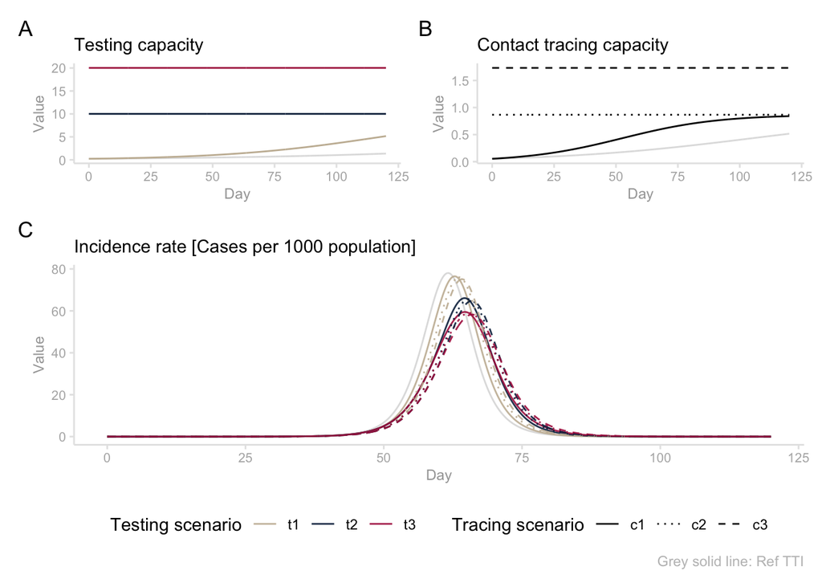

```r
g <- plot_fig_06(cap_df, inc_df, sim_output)

ggsave("./plots/Fig_06_TI_CT_Scenarios.pdf", plot = g,
       height = 7, width = 7, device = cairo_pdf)

g
```

## 2.4 Compliance scenarios

We simulate the TTI model under three scenarios of individual compliance.

```r
iota_high  <- 0.62
delta_high <- 0.9
comp_scn <- data.frame(par_iota_d = c(iota_mid, iota_high, iota_high),
                       par_delta  = c(delta_high, delta_val, delta_high))

fp_ct <- "./models/2C_TTI_Logistic.stmx"

mdl <- read_xmile(fp_ct,
                  list(Qd = data_df[1, 2],
                       Qk = Qk_init),
                  const_list = c(bio_params,
                                 par_zeta = zeta_val,
                                 par_alpha_d = alpha_d_val,
                                 par_alpha_k = alpha_k_val,
                                 par_rho_d   = rho_est,
                                 par_rho_k   = rho_k_est))

comp_sce_df <- sd_sensitivity_run(mdl$deSolve_components,
                                  consts_df = comp_scn,
                                  integ_method = "euler", start_time = 0,
                                  stop_time = 1000, timestep = 1 / 64,
                                  reporting_interval = 1 / 8)
```

## 2.5 Detecting pre-clinical individuals

We simulate a variant of TTI model, where the detection of infectious individuals occurs at the pre-clinical (pre-symptomatic) stage.

```r
comp_scn2 <- bind_rows(data.frame(par_iota_d = iota_mid,
                                  par_delta  = delta_val), comp_scn)

mdl_4d_fp <- "./models/2E_TTI_logistic_pre_symp.stmx"

mdl_4d <- read_xmile(mdl_4d_fp,
                     list(Qd = data_df[1, 2],
                          Qk = Qk_init),
                     const_list = c(bio_params,
                     par_zeta = zeta_val,
                     par_alpha_d = alpha_d_val,
                     par_alpha_k = alpha_k_val,
                     par_rho_d   = rho_est,
                     par_rho_k   = rho_k_est))

mdl_4d_sce_df <- sd_sensitivity_run(mdl_4d$deSolve_components,
                                    consts_df = comp_scn2,
                                    integ_method = "euler", start_time = 0,
                                    stop_time = 500, timestep = 1 / 64,
                                    reporting_interval = 1 / 8)
```

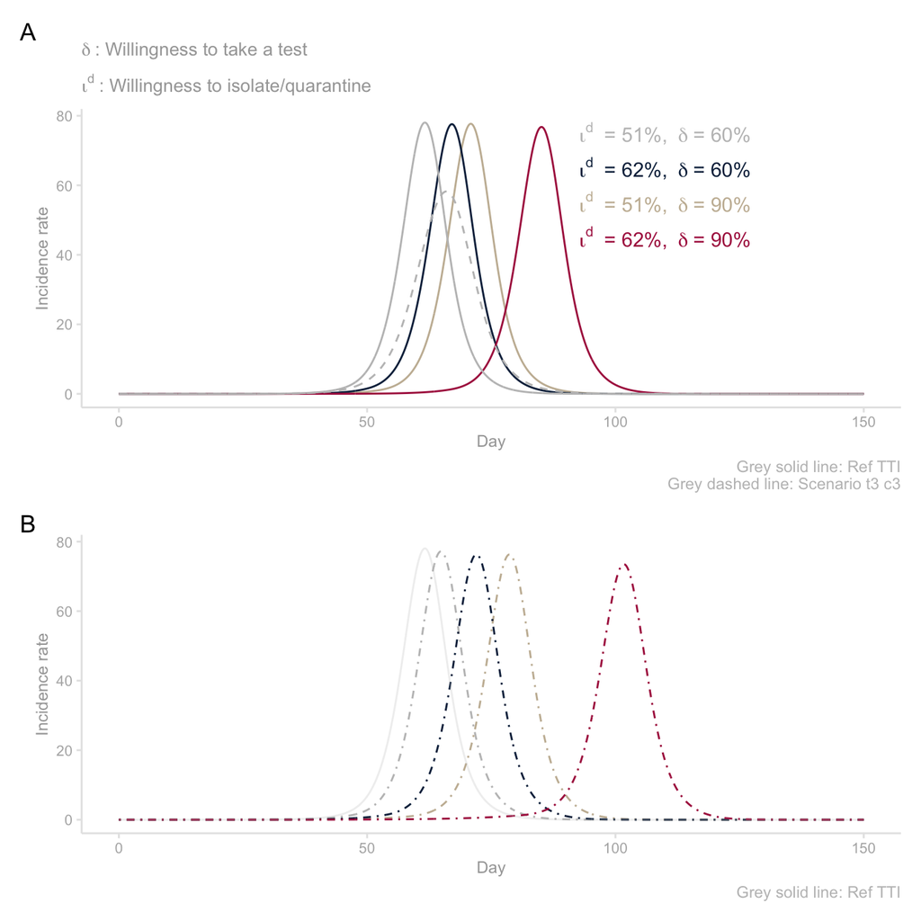

```r
g <- plot_fig_07(comp_sce_df, mdl_4d_sce_df, sim_output, comp_scn, inc_df)

ggsave("./plots/Fig_07_CT_sensitivity.pdf", plot = g,
       height = 6, width = 7, device = cairo_pdf)

g
```

# 3 TTI + mobility restrictions (MR)

```r
mdl_ct_mob_fp <- "./models/2F_TTI_PLUS_MR.stmx"

mdl_ct_mob <- read_xmile(mdl_ct_mob_fp,
                         const_list  = c(bio_params,
                                         par_zeta_0  = zeta_val,
                                         par_alpha_d = alpha_d_val,
                                         par_alpha_k = alpha_k_val,
                                         par_rho_d   = rho_est,
                                         par_rho_k   = rho_k_est,
                                         par_iota_d  = iota_mid,
                                         par_delta   = delta_mid),
                         stock_list = c(Qd = Qd_init,
                                        Qk = Qk_init,
                                        Qm = 90))
```

This code simulates the model that incorporates testing, tracing, and isolation (TTI) and mobility restrictions (MR). In other words, the three non-pharmaceutical interventions explored in this work. This simulation explores three scenarios:

1. Mobility restrictions without TTI
2. TTI + mobility restrictions, where the latter are deployed at day 0
3. TTI + mobility restrictions, where the latter are deployed at day 40

```r
# First scenario: Just MR
# Second scenario: TTI + MR, starting at 0
# Third scenario: TTI + MR, starting at 40
intv_df <- data.frame(par_tau_m = c(0, 0, 40),
                      Qd = c(0, Qd_init, Qd_init),
                      Qm = c(90, 90, 90),
                      itv = c("MR", "TTI + MR", "TTI + MR"),
                      iter = 1:3)

sim_mob_df <- sd_sensitivity_run(mdl_ct_mob$deSolve_components,
                                 consts_df = select(intv_df, par_tau_m),
                                 stocks_df = select(intv_df, Qd, Qm),
                                 start_time = 0,
                                 stop_time = 360,
                                 timestep = 1 / 64, integ_method = "euler",
                               multicore = TRUE, n_cores = 3) |>
  mutate(c = C / N) |>
  left_join(intv_df[, c("iter", "itv")])
```

## 3.1 Sensitivity analysis

This code performs a sensitivity analysis on the *TTI + MR* model. In particular, we draw 10 000 points from a two-dimensional uniform space defined by the compliance parameter ($\xi$) and the time at which mobility restrictions are introduced ($\tau^m$). We subsequently use these points to configure and simulate the *TTI + MR* model. For each simulation, we estimate the attack rate at days 180 & 270.

```r
set.seed(19860618)

grid_df <- expand.grid(par_xi    = seq(from = 0, to = 1, length.out = 100),
                       par_tau_m = seq(from = 0, to = 60, length.out = 100))
```

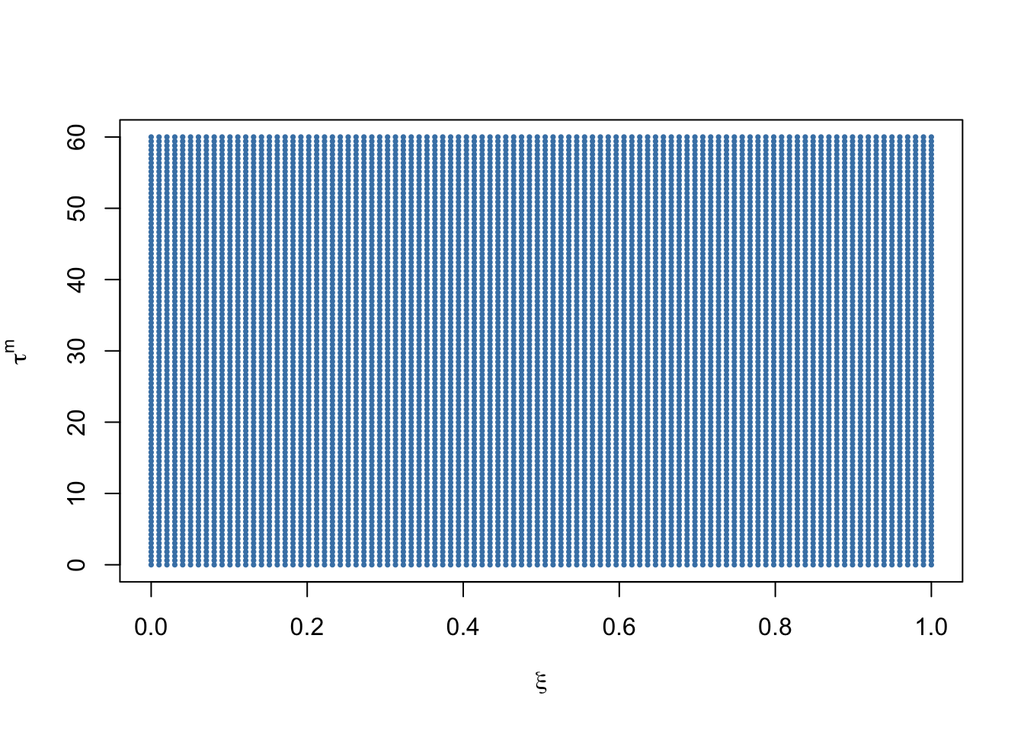

Fig 2. Social distancing exploration space

```r
plot(grid_df, pch = 16, cex = 0.5, col = "steelblue",
     xlab = expression(xi), ylab = expression(tau^m))
```

```r
fp <- "./saved_objects/mob_ct_sens.rds"

if(!file.exists(fp)) {

  sim_mr_scn <- sd_sensitivity_run(mdl_ct_mob$deSolve_components,
                              consts_df = grid_df,
                              start_time = 0,
                              stop_time = 365, timestep = 1/64,
                              integ_method = "euler",
                              multicore = TRUE,
                              reporting_interval = 1) |>
    select(iter, time, C, C_in, par_xi, par_tau_m)


  saveRDS(sim_mr_scn, fp)
} else {
  sim_mr_scn <- readRDS(fp)
}
```

```r
df_2 <- sim_mr_scn |> mutate(attack_rate = 100 * C/ pop_val) |>
  filter(time == 270,
         par_xi < 0.8)

df_2 |> arrange(attack_rate) |> head(10) |>
  select(par_xi, par_tau_m, attack_rate)
```

```
##              par_xi par_tau_m attack_rate
## 172816779 0.7979798  40.60606    26.16993
## 172816778 0.7878788  40.60606    26.34780
## 172816879 0.7979798  41.21212    26.99040
## 172816676 0.7676768  40.00000    27.10025
## 172816777 0.7777778  40.60606    27.40834
## 172816677 0.7777778  40.00000    27.50628
## 172816574 0.7474747  39.39394    27.89950
## 172816675 0.7575758  40.00000    28.06499
## 172816878 0.7878788  41.21212    28.49932
## 172816575 0.7575758  39.39394    28.51805
```

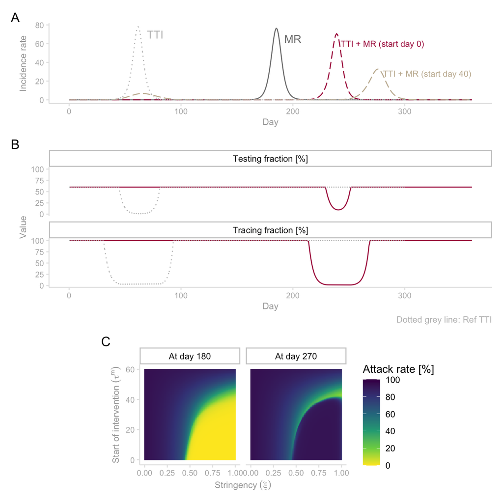

```r
g <- plot_fig_08(sim_mob_df, sim_output, sim_mr_scn)

ggsave("./plots/Fig_08_Mobility.pdf", plot = g,
       height = 7.5, width = 7, device = cairo_pdf)

g
```

[^1]: https://archief51.sitearchief.nl/archives/sitearchief/20230629020000/https://www.diensttesten.nl/over-dienst-testen/historie-van-dienst-testen
[^2]: https://ggdghor.nl/actueel-bericht/werving-bron-en-contactonderzoek/